# Baseball Card Analysis

Jen Estes

16 March, 2025

## Introduction

After investigating the summary statistics Brady presented for me, I am going to begin my model creation to estimate the price of baseball cards based on a variety of variables. To begin, I will start with investigating the relationship between our explanatory and response variables, and then create a regular linear regression model and see how well this model fits the actual prices.

# Variable Relationships

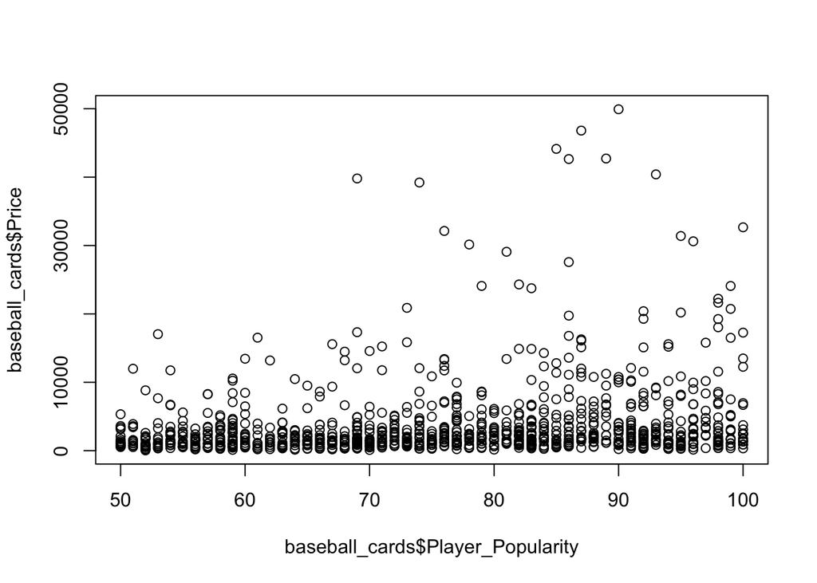

```r
plot(baseball_cards$Player_Popularity, baseball_cards$Price)
```

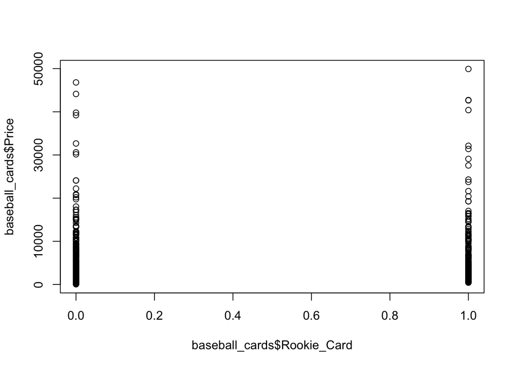

```r
plot(baseball_cards$Rookie_Card, baseball_cards$Price)
```

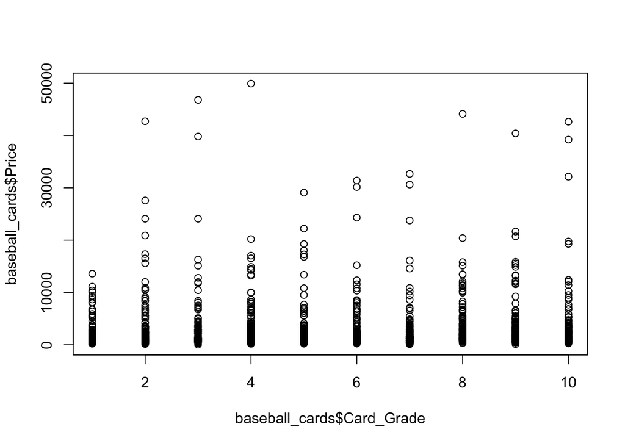

```r
plot(baseball_cards$Card_Grade, baseball_cards$Price)
```

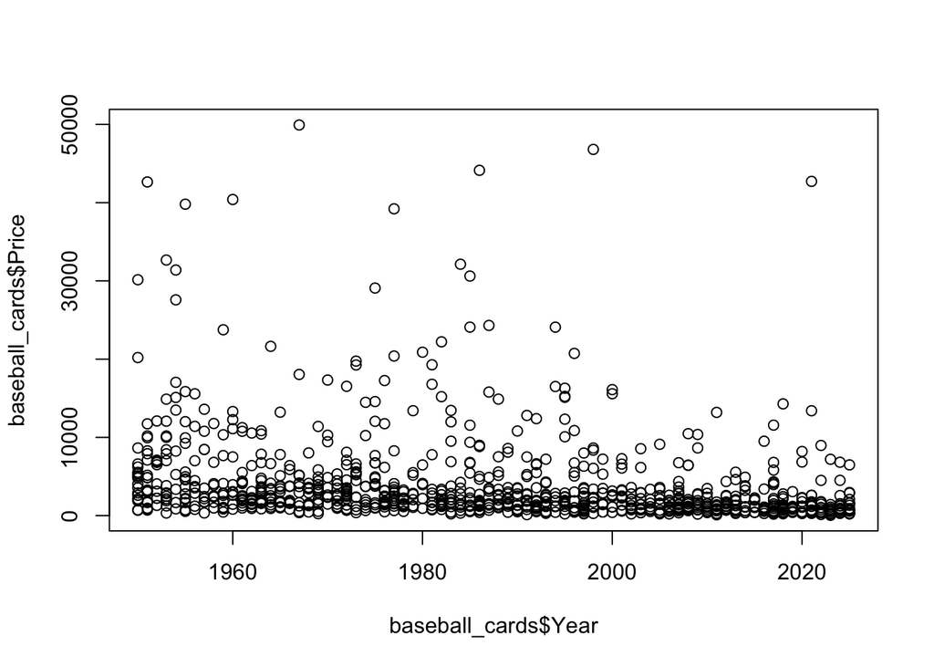

```r
plot(baseball_cards$Year, baseball_cards$Price)
```

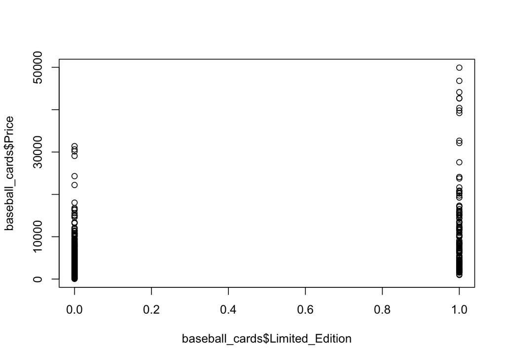

```r
plot(baseball_cards$Limited_Edition, baseball_cards$Price)
```

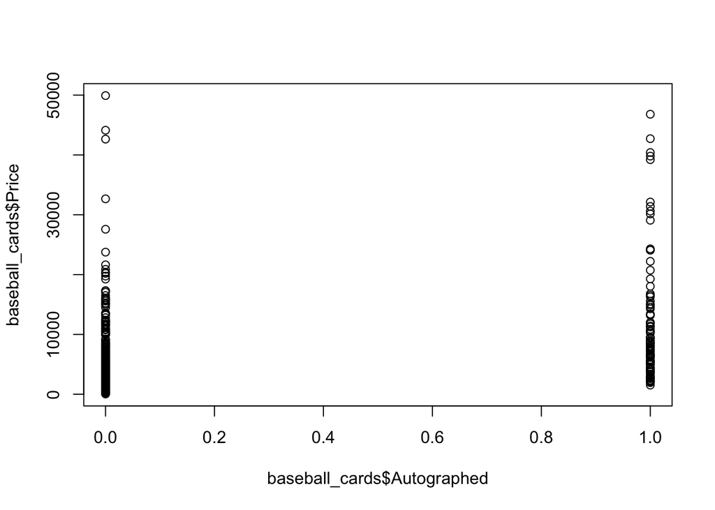

```r
plot(baseball_cards$Autographed, baseball_cards$Price)
```

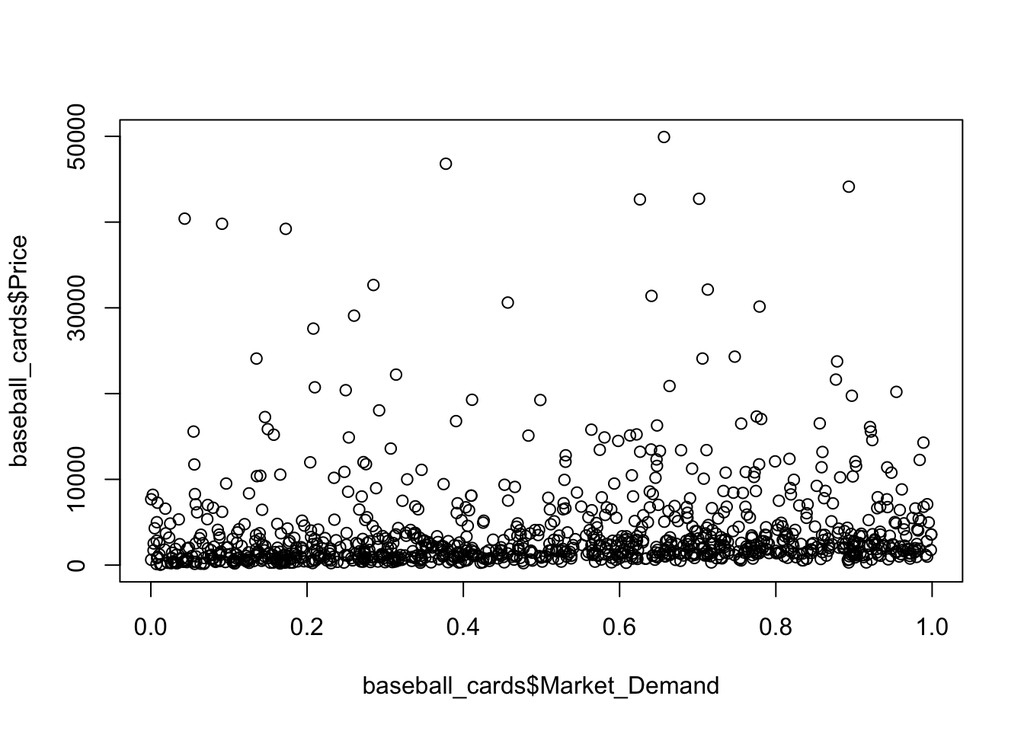

```r
plot(baseball_cards$Market_Demand, baseball_cards$Price)
```

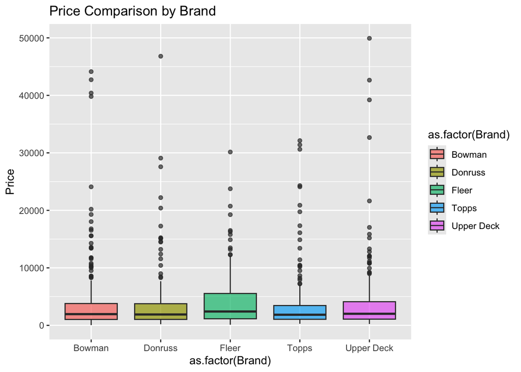

```r
ggplot(baseball_cards, aes(x = as.factor(Brand), y = Price, fill = as.factor(Brand))) +
  geom_boxplot(alpha = 0.7) +
  labs(title = "Price Comparison by Brand") +
  scale_x_discrete(labels = c("0" = "No", "1" = "Yes"))
```

The graphs above help me visualize the relationships between each of the explanatory variables and the response variable of price, and now I will begin creating my model to predict the price of baseball cards.

# Base Model

```r
lm_base <- lm(Price ~ Player_Popularity + Rookie_Card + Card_Grade + Year + Limited_Edition + Brand + Autographed + Market_Demand ,
              data=baseball_cards)
summary(lm_base)
```

```
##
## Call:
## lm(formula = Price ~ Player_Popularity + Rookie_Card + Card_Grade +
##     Year + Limited_Edition + Brand + Autographed + Market_Demand,
##     data = baseball_cards)
##
## Residuals:
##    Min     1Q Median     3Q    Max
## -11846  -1433   -146   1176  36631
##
## Coefficients:
##                     Estimate Std. Error t value Pr(>|t|)
## (Intercept)       117277.856  11050.013  10.613  < 2e-16 ***
## Player_Popularity     80.552      8.539   9.434  < 2e-16 ***
## Rookie_Card         1408.138    267.622   5.262 1.75e-07 ***
## Card_Grade            30.003     42.532   0.705   0.4807
## Year                 -61.826      5.538 -11.163  < 2e-16 ***
## Limited_Edition     7520.532    342.300  21.971  < 2e-16 ***
## BrandDonruss        -883.257    389.794  -2.266   0.0237 *
## BrandFleer          -572.442    380.439  -1.505   0.1327
## BrandTopps          -183.621    373.479  -0.492   0.6231
## BrandUpper Deck     -240.641    381.327  -0.631   0.5281
## Autographed         8854.707    430.347  20.576  < 2e-16 ***
## Market_Demand       2389.775    426.908   5.598 2.81e-08 ***
## ---
## Signif. codes:  0 '***' 0.001 '**' 0.01 '*' 0.05 '.' 0.1 ' ' 1
##
## Residual standard error: 3867 on 988 degrees of freedom
## Multiple R-squared:  0.5529, Adjusted R-squared:  0.5479
## F-statistic: 111.1 on 11 and 988 DF,  p-value: < 2.2e-16
```

This base model provides a start in using the explanatory variables to in a linear regression model to predict the response variable price. However, the R-squared value is only about 0.55, which means that our model is only predicting about 55% of the variation of prices of baseball cards. To make this model more accurate, I will investigate some of the relationships between our explanatory and response variables.

# Refining the Model

```r
# Second Model
lm_second <- lm(log(Price) ~ (Player_Popularity) + (Rookie_Card) + Card_Grade + Brand + Year + (Limited_Edition) + (Autographed) + (Market_Demand),
              data=baseball_cards)
summary(lm_second)
```

```
##
## Call:
## lm(formula = log(Price) ~ (Player_Popularity) + (Rookie_Card) +
##     Card_Grade + Brand + Year + (Limited_Edition) + (Autographed) +
##     (Market_Demand), data = baseball_cards)
##
## Residuals:
##      Min       1Q   Median       3Q      Max
## -1.84840 -0.34661  0.02646  0.38223  1.66644
##
## Coefficients:
##                     Estimate Std. Error t value Pr(>|t|)
## (Intercept)       43.2488761  1.5932436  27.145   <2e-16 ***
## Player_Popularity  0.0181014  0.0012311  14.703   <2e-16 ***
## Rookie_Card        0.4364429  0.0385870  11.311   <2e-16 ***
## Card_Grade         0.0117169  0.0061324   1.911   0.0563 .
## BrandDonruss      -0.1353442  0.0562023  -2.408   0.0162 *
## BrandFleer        -0.0386453  0.0548535  -0.705   0.4813
## BrandTopps         0.0733014  0.0538499   1.361   0.1738
## BrandUpper Deck   -0.0143912  0.0549816  -0.262   0.7936
## Year              -0.0191398  0.0007985 -23.968   <2e-16 ***
## Limited_Edition    1.3561266  0.0493545  27.477   <2e-16 ***
## Autographed        1.5696016  0.0620494  25.296   <2e-16 ***
## Market_Demand      1.0902469  0.0615536  17.712   <2e-16 ***
## ---
## Signif. codes:  0 '***' 0.001 '**' 0.01 '*' 0.05 '.' 0.1 ' ' 1
##
## Residual standard error: 0.5575 on 988 degrees of freedom
## Multiple R-squared:  0.7336, Adjusted R-squared:  0.7306
## F-statistic: 247.3 on 11 and 988 DF,  p-value: < 2.2e-16
```

The model above regresses the natural logarithm of the price of baseball cards on the explanatory variables of player popularity, rookie status, card grade, card brand, year, limited edition status, autographed status, and market demand. Compared to the base model, this second model is able to predict more variation in the price of baseball cards, as the r-squared value is higher. Using these explanatory variables, the model can predict about 73% of the variation in the log price of baseball cards. It seems that all of these explanatory variables are significant in predicting a card’s price excpet for the card brand and card grade. This model can be used to predict the price by transforming the response variable back to price.

# Predictions Using the Model

```r
# Predictions Using Final Model
baseball_cards <- baseball_cards %>%
  mutate(
    predictions = (exp(predict(lm_second,baseball_cards)))
  )

# Residuals- difference between actual price and predicted price
baseball_cards <- baseball_cards %>%
  mutate(residuals = (Price - predictions), baseball_cards)
```

Now, in the baseball cards data set we have a column called “predictions”, which is the predicted price of the baseball card based on our model. We also have a column called “residuals”, which is the difference between the actual price and our model’s predicted price. An ideal model would produce very low residual values because this means the predictions are very close to the actual values.

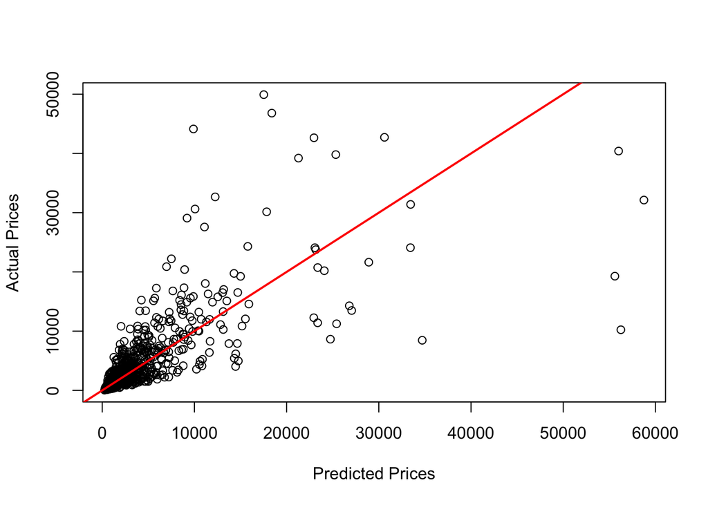

```r
#Plotting the predicted vs. actual values
plot(exp(predict(lm_second)), baseball_cards$Price,
     xlab = "Predicted Prices",
     ylab = "Actual Prices")
     abline(a = 0, b = 1, lwd=2, col = "red")
```

The graph above helps us see that our model does fairly well at predicting the price of baseball cards that are a lower price, but the errors in our predictions get larger as we see higher prices of baseball cards.

# Splitting Data into Testing/Training Sets

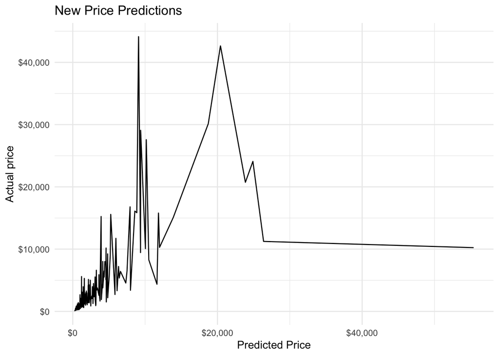

```r
set.seed(20240301)

training_idx <- sample(nrow(baseball_cards),size=round(nrow(baseball_cards)*0.8),replace=F)
testing_idx <- (1:nrow(baseball_cards))[!(1:nrow(baseball_cards)) %in% training_idx]
training_data <- baseball_cards[training_idx,]
testing_data <- baseball_cards[testing_idx,]

refit_final <- update(lm_second,data=training_data)

# Using this model to predict prices
testing_data <- testing_data %>%
  mutate(
    new_predictions = exp(predict(refit_final,testing_data)),
    residuals = Price - new_predictions
  )

#Plotting the new predicted vs. actual values

ggplot(testing_data,
       aes(x= (new_predictions), y = (Price))) +
  geom_line() +
  theme_minimal() +
  labs(x="Predicted Price",
       y="Actual price",
       title="New Price Predictions") +
  scale_y_continuous(label=dollar) +
  scale_x_continuous(label=dollar)
```

The plot above shows the comparison of the new predicted values with the updated model in comparison to the true prices, which shows this model is best when predicting lower priced baseball cards. However, with baseball cards of at higher price levels, the predictions might become less accurate. Finally, we can look at the residuals, which are the differences in price between the model’s predictions and the actual price.

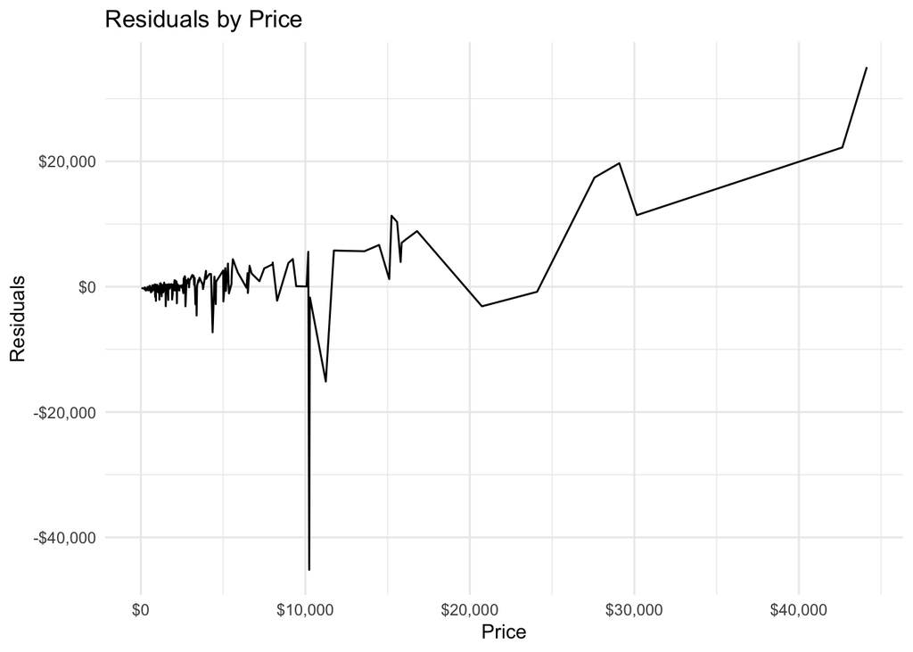

```r
ggplot(testing_data,
       aes(x= (Price), y = (residuals))) +
  geom_line() +
  theme_minimal() +
  labs(x="Price",
       y="Residuals",
       title="Residuals by Price") +
  scale_y_continuous(label=dollar) +
  scale_x_continuous(label=dollar)
```

This visual is helpful in understanding the success of our model, and it is clear that for baseball cards that are less than about $5,000, our model is fairly accurate because the residuals are close to 0. However, as the price increases, our predictions on the price of baseball cards becomes less accurate.

# Classification Trees - NEED EDITS

```r
#Summary Stats
summary(baseball_cards)

#Create a training and testing dataset
#This takes number of rows and divides by two for a 50/50 split
bound <- floor((nrow(baseball_cards)/2))

#This randomly shuffles the entire dataset
baseball_cards <- baseball_cards[sample(nrow(baseball_cards)),]

#Create a new dataframe called data.train that contains record #1 to "bound"
data.train <- baseball_cards[1:bound, ]

#Create a new dataframe called data.test that contains record "bound" to the end of the dataframe
data.test <- baseball_cards[(bound+1):nrow(baseball_cards), ]

#create decision tree using rpart
#This is your model!
tree <- rpart(log(Price) ~ (Player_Popularity) + (Rookie_Card) + Card_Grade + Brand + Year + (Limited_Edition) + (Autographed) + Market_Demand, method = "class",
              data=data.train)

#Assigning dependent variable of Price
depvariable <- "log(Price)"

##Make sure that it has more than 14

#Display decision tree- FIX HERE
plot(tree, uniform = TRUE, margin=.05)
```

[output not shown]

[output not shown]

```r
text(tree, use.n=TRUE, all=TRUE, cex=0.6)
```

[output not shown]

[figure not shown]

```r
#predict the outcome using the test dataset
pred1 <- predict(tree, data.test, type="class")

#Place the prediction variable back in the test dataset
data.test$pred1 <- pred1

#Display Confusion Matrix - this is the correct display of the table.
rtable<-table(data.test$Price,data.test$pred1, dnn=c("Actual", "Predicted"))
rtable

#Display accuracy rate
sum(data.test$Price==pred1)/length(pred1)

#true positive rate:
tpr <- sum(rtable[2,2])/sum(rtable[2,])

#false positive rate:
fpr <- sum(rtable[1,2])/sum(rtable[1,])

######
#ROC Curve
#The only think you need to change below is:
#1) the name of your datasets. For example, grad.test$ below should be the name of your testing dataset.
#2) On lines 99 and 100, the 1 and 0 should reflect the values of your depedent variable.
######

# for ROC curve we need probabilties so we can sort grad.test
data.test$probs <- predict(tree,data.test, type="prob")[,2] # returns prob of both cats, just need 1

roc.data <- data.frame(cutoffs = c(1,sort(unique(data.test$probs),decreasing=T)),
                       TP.at.cutoff = 0,
                       TN.at.cutoff = 0)

for(i in 1:dim(roc.data)[1]){
  this.cutoff <- roc.data[i,"cutoffs"]
  roc.data$TP.at.cutoff[i] <- sum(data.test[data.test$probs >= this.cutoff,depvariable] == 1)
  roc.data$TN.at.cutoff[i] <- sum(data.test[data.test$probs < this.cutoff,depvariable] == 0)
}
roc.data$TPR <- roc.data$TP.at.cutoff/max(roc.data$TP.at.cutoff)
roc.data$Specificity <- roc.data$TN.at.cutoff/max(roc.data$TN.at.cutoff)
roc.data$FPR <- 1 - roc.data$Specificity

with(roc.data,
     plot(x=FPR,
          y=TPR,
          type = "l",
          xlim=c(0,1),
          ylim=c(0,1),
          main="ROC Curve'")
)
abline(c(0,1),lty=2)
```

[output not shown]

```r
######End ROC code
```